# Untitled

2022-08-13

# Problema dos testes de diagnóstico

Informacão disponível:

- Teste de varredura (screening) para uma determinada doença
- Testes são imperfeitos, suponha que acerta 90% dos que tem doença (sensibilidade) e 80% dos que não tem (especificidade)
- A doençaa ocorre em 2% da populacão (prevalência)

Pergunta de interesse: Se uma pessoa testou positivo, qual a chance de ter a doença? (valor preditivo positivo)

- População:
  - Doentes: 2%
    - Verdadeiros positivos: 90%
    - Falsos negativos: 10%
  - Não doentes: 98%
    - Verdadeiros negativos: 80%
    - Falsos positivos: 20%

Definção dos eventos:

$D$: ter a determinada doença $S$: testar positivo para a determinada doença

**Teorema de Bayes:**

$P(D \mid S) = \dfrac{P(S \mid D)P(D)}{P(S \mid D)P(D) + P(S \mid D^c)P(D^c)}$

$P(D \mid S) = \dfrac{0.9 \cdot 0.02}{0.9 \cdot 0.02 + 0.2 \cdot 0.98}$

$P(D \mid S) = \dfrac{0.018}{0.018 + 0.196} = 0.08411215$

**Adaptando a notação:**

- Probabilidade inicial (a priori)
  - Estado $\theta = 1$ (doente), $\theta = 0$ caso contrário
  - $P(\theta = 1) = 0.02$
  - $P(\theta = 0) = 0.98$
- Dado/informação:
  - $Y = 1$ se o teste for positivo, $Y = 0$ caso contrário
  - $P(Y = 1 \mid \theta = 1) = 0.9$
  - $P(Y = 1 \mid \theta = 0) = 0.2$
  - $P(Y = 0 \mid \theta = 1) = 0.1$
  - $P(Y = 0 \mid \theta = 0) = 0.8$
- Probabilidades atualizadas (a posteriori)
  - $P(\theta = 1) = 0.08411215$
  - $P(\theta = 0) = 0.9158879$

# Estimando uma proporção

Em uma população (considerada infinita) uma proporção $\theta$ de indivíduos apresenta determinada característica.

Deseja-se:

- Estimar $\theta$;
- Expressar a incerteza sobre esta estimativa;
- Verificar se $\theta$ (e portanto a população) ultrapassa 20%

Portanto, os objetivos são:

- Estimativa de $\theta$;
- Expressão da incerteza;
- Opinião em relação ao valor de interesse ($\theta_0 = 0.2$)

Considerando a seguinte amostra:

$\mathbf{x} = (0,0,1)^T$

- n = 3
- y = 1 (indivíduos com a determinada característica)

Cada indivíduo amostrado é um ensaio de Bernoulli, com função de probabilidade:

$P(X = x \mid \theta) = \theta^{x}(1 - \theta)^{1 - x}$, $x \in \{ 0,1 \}$.

Sendo assim, denotamos $X \sim \text{Ber}(\theta)$.

Considerando $Y$ o número de sucessos em $n$ ensaios de Bernoulli, denotamos $Y \sim \text{Bin}(\theta)$ com função de probabilidade. Para calcular a probabilidade de 1 sucesso em 3 ensaios:

$P(Y = 1 \mid n = 3, \theta) = P(X = 0 \mid \theta) \cdot P(X = 0 \mid \theta) \cdot P(X = 1 \mid \theta) + P(X = 0 \mid \theta) \cdot P(X = 1 \mid \theta) \cdot P(X = 0 \mid \theta) + P(X = 1 \mid \theta) \cdot P(X = 0 \mid \theta) \cdot P(X = 0 \mid \theta)$

$P(Y = y \mid n, \theta) = \binom{n}{y} \theta^{y} (1 - \theta)^{n - y}$

$P(Y = y \mid n, \theta) = \dfrac{n!}{y!(n - y)!} \theta^{y} (1 - \theta)^{n - y}$

Avaliando a probabilidade de obter $y = 19$ de indivíduos com a característica de interesse, em uma amostra de $n = 80$ indivíduos.

$P(Y = 19 \mid n=80, \theta) = \binom{80}{19} \theta^{19} (1 - \theta)^{80 - 19}$

Como esta probabilidade muda para cada possível valor de $\theta$?

**Função de verossimilhança:**

$L(\theta \mid n, y) L(\theta) = \binom{n}{y} \theta^{y} (1 - \theta)^{n - y}$

$L(\theta) = \binom{80}{19} \theta^{19} (1 - \theta)^{80 - 19}$

Qual é a probabilidade de observar $y=19$ em $n = 80$, se o parâmetro populacional fosse $\theta = 0.2375$?

$L(\theta = 0.2375 \mid n = 80, y = 19) = \binom{80}{19} 0.2375^{19} (1 - 0.2375)^{80 - 19} = 0.1043201$

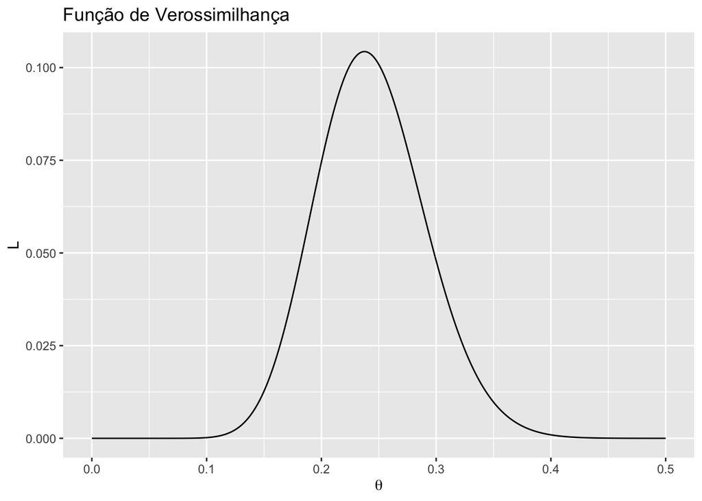

```r
y = 19
n = 80
theta <- seq(0, 1, 0.001)

L_bin <- function(theta, n, y) dbinom(x = y, size = n, prob = theta)

L <- L_bin(theta, n, y)
df_plot <- data.frame(theta, L)
df_plot |>
  ggplot(aes(x = theta, y = L)) +
  geom_line() +
  labs(title = 'Função de Verossimilhança', x = expression(theta), y = expression(L)) +
  xlim(0, 0.5)
```

**Função de log-verossimilhança:**

$l(\theta) = \ln \left[ L(\theta) \right]$

$l(\theta) = \ln \left[ \binom{n}{y} \theta^{y} (1 - \theta)^{n - y} \right]$

$l(\theta) = \ln\binom{n}{y} + y \ln(\theta) + (n - y) \ln(1 - \theta)$

$l(\theta) = \ln\binom{80}{19} + 19 \ln(\theta) + (80 - 19) \ln(1 - \theta)$

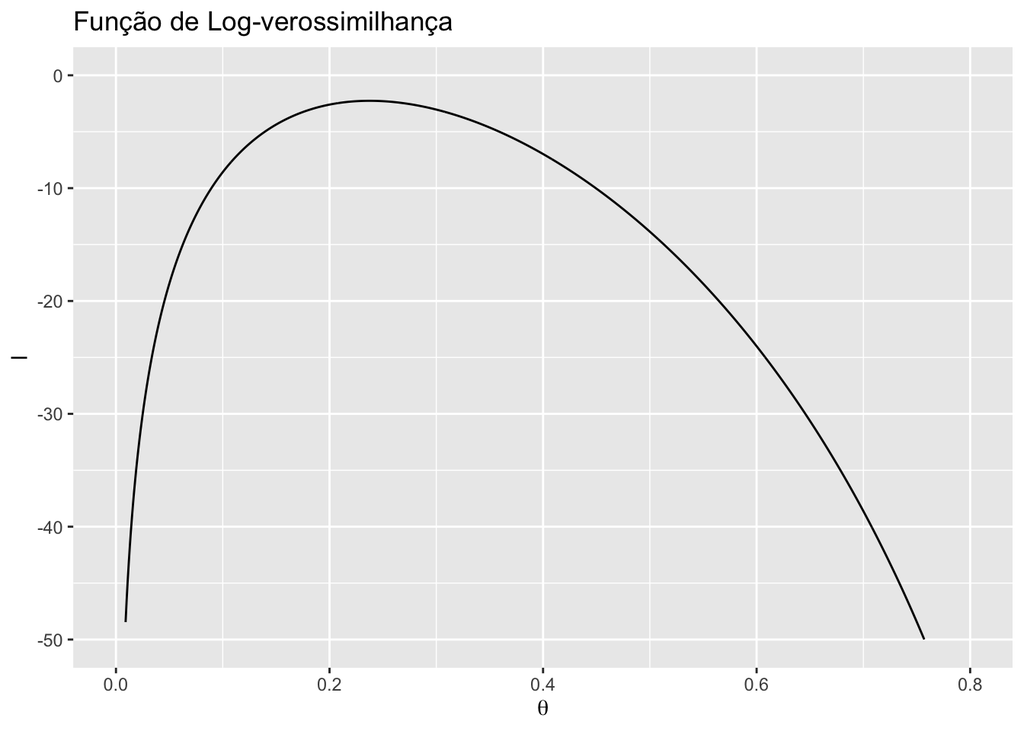

```r
l_bin <- function(theta, n, y) log(L_bin(theta, n, y))

df_plot$l <- l_bin(theta, n, y)
df_plot |>
  ggplot(aes(x = theta, y = l)) +
  geom_line() +
  labs(title = 'Função de Log-verossimilhança', x = expression(theta), y = expression(l)) +
  ylim(-50, 0) +
  xlim(0, 0.8)
```

**EMV (solução analítica)**

$U(\theta) = \dfrac{d}{d \theta} l(\theta)$

$U(\theta) = \dfrac{d}{d \theta} \left\{ \ln\binom{n}{y} + y \ln(\theta) + (n - y) \ln(1 - \theta) \right\}$

$U(\theta) = \dfrac{y}{\theta} - \dfrac{n-y}{1-\theta}$

$U(\hat{\theta}) = 0$

$\dfrac{y}{\hat{\theta}} - \dfrac{n-y}{1-\hat{\theta}} = 0$

$\dfrac{y}{\hat{\theta}} = \dfrac{n-y}{1-\hat{\theta}}$

$\dfrac{y(1-\hat{\theta})}{\hat{\theta}} = n-y$

$y(1-\hat{\theta}) = \hat{\theta}(n-y)$

$y - y\hat{\theta} = n\hat{\theta} - y\hat{\theta}$

$n\hat{\theta} = y$

$\hat{\theta} = \dfrac{y}{n}$

$\hat{\theta} = \dfrac{19}{80} = 0.2375$

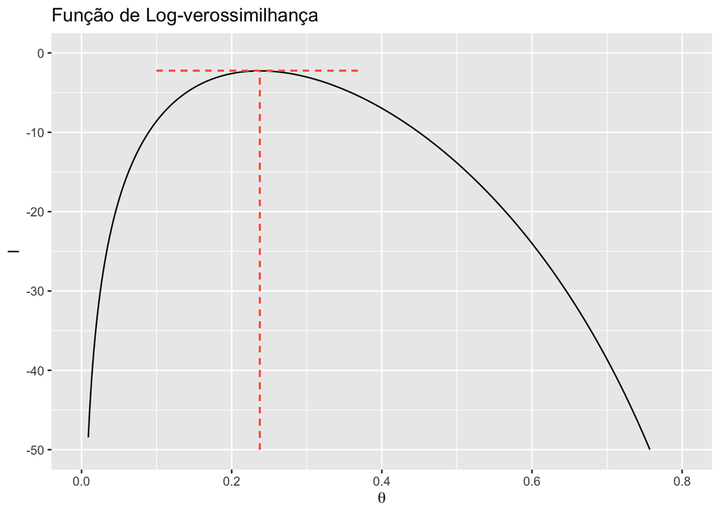

```r
theta_hat = y/n
max_ll <- l_bin(theta_hat, n, y)
min_ll <- -50

df_plot |>
  ggplot(aes(x = theta, y = l)) +
  geom_line() +
  labs(title = 'Função de Log-verossimilhança', x = expression(theta), y = expression(l)) +
  ylim(-50, 0) +
  xlim(0, 0.8) +
  geom_segment(
    aes(x = theta_hat, y = min_ll, xend = theta_hat, yend = max_ll),
    linetype = 'dashed', colour = 'tomato') +
  geom_segment(
    aes(x = 0.1, y = max_ll, xend = 0.375, yend = max_ll),
    linetype = 'dashed', colour = 'tomato')
```

**EMV (solução numérica)**

```r
n = 80
y = 19
fit_ll <- optimize(l_bin, n = n, y = y, interval = c(0,1), maximum = T)

theta_hat <- fit_ll$maximum
max_ll <- fit_ll$objective

theta_hat
```

```
## [1] 0.237502
```

**Função de Verossimilhança Relativa:**

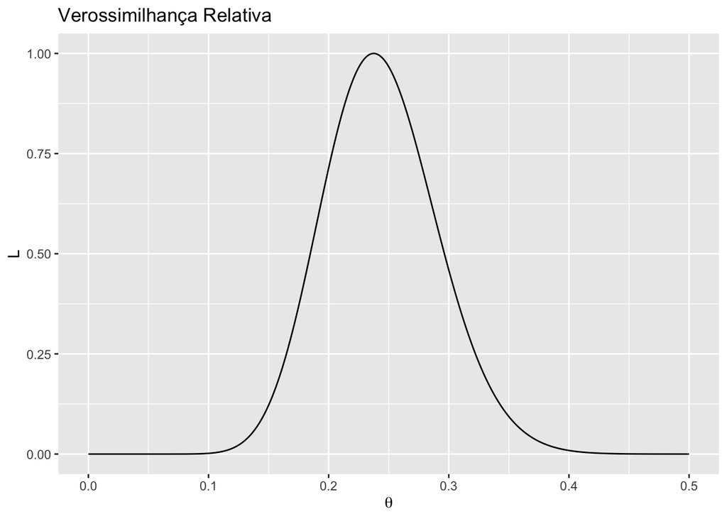

```r
LR_bin <- function(theta, n, y, theta_hat) L_bin(theta, n, y) / L_bin(theta_hat, n, y)

LR <- LR_bin(theta, n, y, theta_hat)
df_plot <- data.frame(theta, LR)
df_plot |>
  ggplot(aes(x = theta, y = LR)) +
  geom_line() +
  labs(title = 'Verossimilhança Relativa', x = expression(theta), y = expression(L)) +
  xlim(0, 0.5)
```

**Deviance**

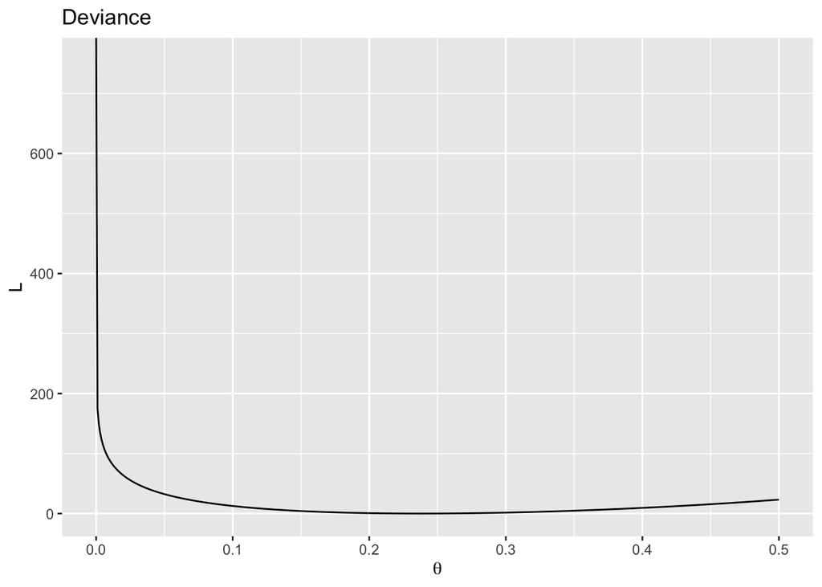

```r
D_bin <- function(theta, n, y, theta_hat) -2*log(LR_bin(theta, n, y, theta_hat))

D <- D_bin(theta, n, y, theta_hat)
df_plot <- data.frame(theta, D)
df_plot |>
  ggplot(aes(x = theta, y = D)) +
  geom_line() +
  labs(title = 'Deviance', x = expression(theta), y = expression(L)) +
  xlim(0, 0.5)
```

**Raíz da Deviance**

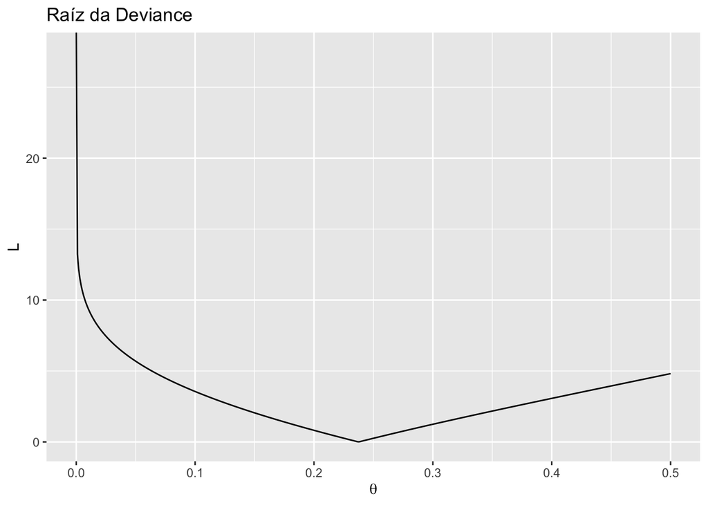

```r
RD_bin <- function(theta, n, y, theta_hat) sqrt(D_bin(theta, n, y, theta_hat))

RD <- RD_bin(theta, n, y, theta_hat)
df_plot <- data.frame(theta, RD)
df_plot |>
  ggplot(aes(x = theta, y = RD)) +
  geom_line() +
  labs(title = 'Raíz da Deviance', x = expression(theta), y = expression(L)) +
  xlim(0, 0.5)
```

**Erro padrão (solução analítica)**

$\text{s.e.}(\hat{\theta}) = \sqrt{-H(\hat{\theta})^{-1}}$

$H(\hat{\theta}) = \dfrac{d}{d\hat{\theta}} U(\hat{\theta})$

$H(\hat{\theta}) = \dfrac{d}{d\hat{\theta}} \left[ \dfrac{y}{\hat{\theta}} - \dfrac{n-y}{1-\hat{\theta}} \right]$

$H(\hat{\theta}) = y \dfrac{d}{d\hat{\theta}} \hat{\theta}^{-1} - (n - y) \dfrac{d}{d\hat{\theta}} (1-\hat{\theta})^{-1}$

$H(\hat{\theta}) = -\dfrac{y}{\hat{\theta}^2} - \dfrac{n - y}{(1 - \hat{\theta})^2}$

$H(\hat{\theta}) = - \left( \dfrac{y}{\hat{\theta}^2} + \dfrac{n - y}{(1 - \hat{\theta})^2} \right)$

$H(\hat{\theta}) = - \left( \dfrac{19}{0.2375^2} + \dfrac{80 - 19}{(1 - 0.2375)^2} \right)$

$H(\hat{\theta}) = - \left( 336.8421 + 104.918 \right) = - 441.7601$

$\text{s.e.}(\hat{\theta}) = \sqrt{441.7601^{-1}} = 0.04757806$

**Erro padrão (solução numérica)**

```r
H <- drop(numDeriv:::hessian(l_bin, x = fit_ll$max, y = y, n = n))

se <- sqrt(-1/H)
se
```

```
## [1] 0.04757833
```

**Intervalo de confiança**

Limite inferior: $\hat{\theta} - \text{s.e.}(\hat{\theta}) = 0.2375 - 0.04757806 = 0.1899219$

Limite superior: $\hat{\theta} + \text{s.e.}(\hat{\theta}) = 0.2375 + 0.04757806 = 0.2850781$

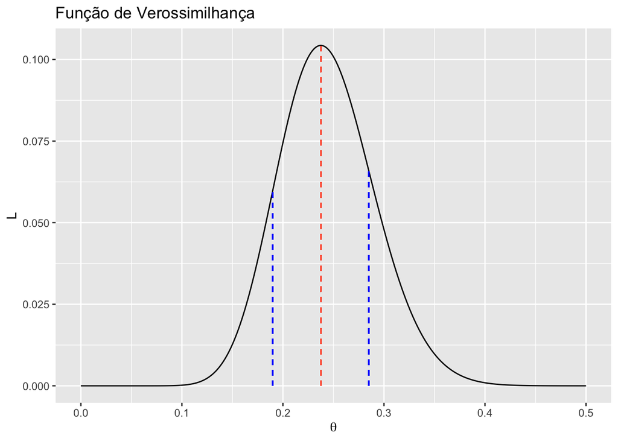

```r
theta_hat <- y/n
theta_inf <- theta_hat - se
theta_sup <- theta_hat + se

max_L <- L_bin(theta_hat, n, y)
min_L <- 0

L_inf <- L_bin(theta_inf, n, y)
L_sup <- L_bin(theta_sup, n, y)

df_plot %>%
  ggplot(aes(x = theta, y = L)) +
  geom_line() +
  labs(title = 'Função de Verossimilhança', x = expression(theta), y = expression(L)) +
  xlim(0, 0.5) +
  geom_segment(
    aes(x = theta_hat, y = min_L, xend = theta_hat, yend = max_L),
    linetype = 'dashed', colour = 'tomato') +
  geom_segment(
    aes(x = theta_inf, y = min_L, xend = theta_inf, yend = L_inf),
    linetype = 'dashed', colour = 'blue') +
  geom_segment(
    aes(x = theta_sup, y = min_L, xend = theta_sup, yend = L_sup),
    linetype = 'dashed', colour = 'blue')
```

# Estimando uma proporção (dados imprecisos)

E se o dado fosse um pouco diferente: em 80 indivíduos não se sabe exatamente quantos contém o atributo, mas sabe-se que são entre 13 e 25 indivíduos:

```r
y1 = 13
y2 = 25

# Função de verossimilhança para observação intervalar:
L_bin_i <- function(theta, n, y1, y2) pbinom(y2, size=n, prob=theta) - pbinom(y1-1, size=n, prob=theta)

# Função de log-verossimilhança para observação intervalar:
l_bin_i <- function(theta, n, y1, y2) log(L_bin_i(theta=theta, n=n, y1=y1, y2=y2))

# Estimativa:
max_lli <- optimize(l_bin_i,n ,y1, y2, interval=c(0,1), maximum=TRUE)
max_lli
```

```
## $maximum
## [1] 0.2342135
##
## $objective
## [1] -0.08941884
```

```r
# Erro padrão:
sei <- sqrt(-1/drop(numDeriv:::hessian(l_bin_i, x=max_lli$max, n=n, y1=y1, y2=y2)))
sei
```

```
## [1] 0.08109633
```

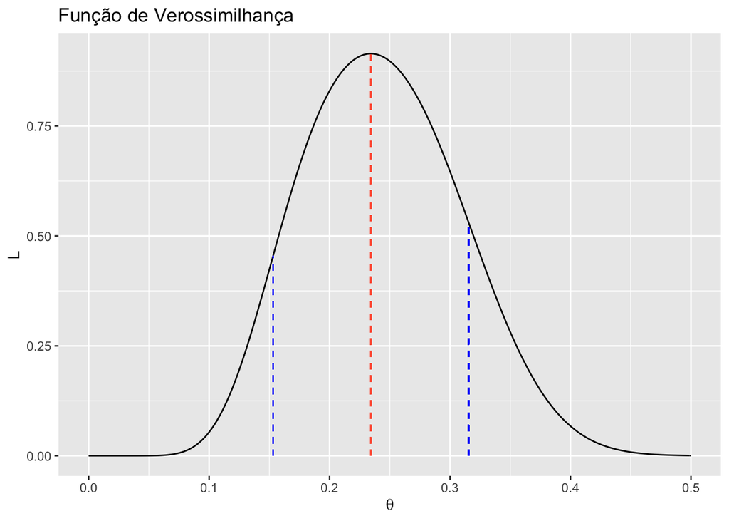

```r
theta_hat <- max_lli$max
theta_inf <- theta_hat - sei
theta_sup <- theta_hat + sei

max_L <- L_bin_i(theta_hat, n, y1, y2)
min_L <- 0

L_inf <- L_bin_i(theta_inf, n, y1, y2)
L_sup <- L_bin_i(theta_sup, n, y1, y2)

theta <- seq(0, 1, 0.001)
L <- L_bin_i(theta, n, y1, y2)
df_plot <- data.frame(theta, L)

df_plot %>%
  ggplot(aes(x = theta, y = L)) +
  geom_line() +
  labs(title = 'Função de Verossimilhança', x = expression(theta), y = expression(L)) +
  xlim(0, 0.5) +
  geom_segment(
    aes(x = theta_hat, y = min_L, xend = theta_hat, yend = max_L),
    linetype = 'dashed', colour = 'tomato') +
  geom_segment(
    aes(x = theta_inf, y = min_L, xend = theta_inf, yend = L_inf),
    linetype = 'dashed', colour = 'blue') +
  geom_segment(
    aes(x = theta_sup, y = min_L, xend = theta_sup, yend = L_sup),
    linetype = 'dashed', colour = 'blue')
```

# Estimando um parâmetro da distribuição Poisson

Suponha que o número diário de vendas de um produto ($Y$) tem distribuição Poisson e que em um período obteve-se os seguintes valores: $\mathbf{y} = (12, 7, 8, 5, 11, 9, 10, 8)^T$.

$Y \sim \text{Pois}(\lambda)$

$P(Y = y \mid \lambda) = \dfrac{e^{-\lambda} \lambda^y}{y!}$, $y \in \{0, 1, 2, \ldots \}$.

Assumindo que cada valor de $\mathbf{y}$ é independente e identicamente distribuído, temos

**Função de verossimilhança**

$L(\lambda \mid \mathbf{y}) = L(\lambda) = \prod\limits_{i=1}^n P(Y = y_i)$

$L(\lambda) = \prod\limits_{i=1}^n \dfrac{e^{-\lambda} \lambda^{y_i}}{y_i!}$

$L(\lambda) = \dfrac{\prod_{i=1}^n e^{-\lambda} \lambda^{y_i}}{ \prod_{i=1}^n y_i!}$

$L(\lambda) = \dfrac{(e^{-\lambda})^n \prod_{i=1}^n \lambda^{y_i}}{ \prod_{i=1}^n y_i!}$

$L(\lambda) = \dfrac{(e^{-\lambda})^n \lambda^{y_1 + \ldots + y_n}}{ \prod_{i=1}^n y_i!}$

$L(\lambda) = \dfrac{e^{- n\lambda} \lambda^{\sum_{i=1}^n y_i}}{ \prod_{i=1}^n y_i!}$

[figure not shown]

```r
y <- c(12, 7, 8, 5, 11, 9, 10, 8)
theta <- seq(1, 20, 0.01)

L_pois <- function(theta, y_i) prod(dpois(x = y, lambda = theta))

f_plot = data.frame(theta = theta)
df_plot$L <- sapply(df_plot$theta, FUN = L_pois, y_i = y)

df_plot %>%
  ggplot(aes(x = theta, y = L)) +
  geom_line() +
  labs(title = 'Função de Verossimilhança', x = expression(lambda), y = expression(L)) +
  xlim(3, 15)
```

**Função de log-verossimilhança**

$l(\lambda \mid \mathbf{y}) = l(\lambda) = \ln \left[ L(\lambda) \right]$

$l(\lambda) = \ln \left[ \dfrac{e^{- n\lambda} \lambda^{\sum_{i=1}^n y_i}}{ \prod_{i=1}^n y_i!} \right]$

$l(\lambda) = \ln \left[ e^{- n\lambda} \lambda^{\sum_{i=1}^n y_i} \right] - \ln \left[ \prod\limits_{i=1}^n y_i! \right]$

$l(\lambda) = -n\lambda \ln(e) + \sum\limits_{i=1}^n y_i \ln(\lambda) - \sum\limits_{i=1}^n \ln(y_i!)$

$l(\lambda) = -n\lambda + \sum\limits_{i=1}^n y_i \ln(\lambda) - \sum\limits_{i=1}^n \ln(y_i!)$

[figure not shown]

```r
l_pois <- function(theta, y_i) sum(dpois(x = y, lambda = theta, log = T))

df_plot$l <- sapply(df_plot$theta, FUN = l_pois, y_i = y)

df_plot %>%
  ggplot(aes(x = theta, y = l)) +
  geom_line() +
  labs(title = 'Função de Log-verossimilhança', x = expression(lambda), y = expression(l))
```

**EMV (solução analítica)**

$U(\lambda) = \dfrac{d}{d\lambda} l(\lambda)$

$U(\lambda) = \dfrac{d}{d\lambda} \left[ -n\lambda + \sum\limits_{i=1}^n y_i \ln(\lambda) - \sum\limits_{i=1}^n \ln(y_i!) \right]$

$U(\lambda) = \dfrac{\sum_{i=1}^n y_i}{\lambda} - n$

$U(\hat{\lambda}) = 0$

$\dfrac{\sum_{i=1}^n y_i}{\hat{\lambda}} - n = 0$

$\dfrac{\sum_{i=1}^n y_i}{\hat{\lambda}} = n$

$\hat{\lambda} = \dfrac{\sum_{i=1}^n y_i}{n}$

$\hat{\lambda} = \dfrac{70}{8} = 8.75$

[figure not shown]

```r
theta_hat <- mean(y)
max_ll <- l_pois(theta = theta_hat, y_i = y)
min_ll <- min(df_plot$l)

df_plot %>%
  ggplot(aes(x = theta, y = l)) +
  geom_line() +
  labs(title = 'Função de Log-verossimilhança', x = expression(lambda), y = expression(l)) +
  geom_segment(
    aes(x = theta_hat, y = min_ll, xend = theta_hat, yend = max_ll),
    linetype = 'dashed', colour = 'tomato') +
  geom_segment(
    aes(x = 7, y = max_ll, xend = 10.5, yend = max_ll),
    linetype = 'dashed', colour = 'tomato')
```

**EMV (solução numérica)**

```r
fit_ll <- optimize(l_pois, y_i = y, interval = c(0,16), maximum = T)

fit_ll
```

```
## $maximum
## [1] 8.749999
##
## $objective
## [1] -18.08386
```

**Erro padrão (solução analítica)**

$\text{s.e.}(\hat{\lambda}) = \sqrt{-H(\hat{\lambda})^{-1}}$

$H(\hat{\lambda}) = \dfrac{d}{d\hat{\lambda}} U(\hat{\lambda})$

$H(\hat{\lambda}) = \dfrac{d}{d\hat{\lambda}} \left[ \dfrac{\sum_{i=1}^n y_i}{\hat{\lambda}} - n\right]$

$H(\hat{\lambda}) = \sum\limits_{i=1}^n y_i \dfrac{d}{d\hat{\lambda}} \hat{\lambda}^{-1} - \dfrac{d}{d\hat{\lambda}} n$

$H(\hat{\lambda}) = -\dfrac{\sum_{i=1}^n y_i}{\hat{\lambda}^2}$

$H(\hat{\lambda}) = -\dfrac{70}{8.75^2} = - 0.9142857$

$\text{s.e.}(\hat{\lambda}) = \sqrt{0.9142857^{-1}} = 1.045825$

**Erro padrão (solução numérica)**

```r
H <- drop(numDeriv:::hessian(l_pois, x = fit_ll$max, y_i = y))
se <- sqrt(-1/H)
se
```

```
## [1] 1.045825
```

**Intervalo de confiança**

Limite inferior: $\hat{\lambda} - \text{s.e.}(\hat{\lambda}) = 8.75 - 1.045825 = 7.704175$

Limite superior: $\hat{\lambda} + \text{s.e.}(\hat{\lambda}) = 8.75 + 1.045825 = 9.795825$

[figure not shown]

```r
theta_hat <- mean(y)
theta_inf <- 7.704175
theta_sup <- 9.795825

max_L <- L_pois(theta = theta_hat, y_i = y)
min_L <- min(df_plot$L)

L_inf <- L_pois(theta = theta_inf, y_i = y)
L_sup <- L_pois(theta = theta_sup, y_i = y)

df_plot %>%
  ggplot(aes(x = theta, y = L)) +
  geom_line() +
  labs(title = 'Função de Verossimilhança', x = expression(lambda), y = expression(L)) +
  xlim(3, 15) +
  geom_segment(
    aes(x = theta_hat, y = min_L, xend = theta_hat, yend = max_L),
    linetype = 'dashed', colour = 'tomato') +
  geom_segment(
    aes(x = theta_inf, y = min_L, xend = theta_inf, yend = L_inf),
    linetype = 'dashed', colour = 'blue') +
  geom_segment(
    aes(x = theta_sup, y = min_L, xend = theta_sup, yend = L_sup),
    linetype = 'dashed', colour = 'blue')
```

**Função de verosimilhança relativa**

$\text{LR}(\lambda) = \dfrac{L(\lambda)}{L(\hat{\lambda})}$

[figure not shown]

```r
LR_pois <- function(theta, y_i, theta_hat) L_pois(theta, y_i) / L_pois(theta_hat, h_i)

df_plot$R <- sapply(df_plot$theta, FUN = LR_pois, y_i = y, theta_hat = theta_hat)

df_plot %>%
  ggplot(aes(x = theta, y = R)) +
  geom_line() +
  labs(title = 'Função de Verossimilhança Relativa', x = expression(lambda), y = expression(LR)) +
  xlim(3, 15)
```

**Deviance**

$D(\lambda) = -2 \ln \left[ \text{LR}(\lambda) \right]$

$D(\lambda) = -2 \ln \left[ \dfrac{L(\lambda)}{L(\hat{\lambda})} \right]$

$D(\lambda) = -2\left[ \ln L(\lambda) - \ln L(\hat{\lambda}) \right]$

$D(\lambda) = -2\left[ l(\lambda) - l(\hat{\lambda}) \right]$

[figure not shown]

```r
D_pois <- function(theta, y_i, theta_hat) -2*log(LR_pois(theta, y_i, theta_hat))

df_plot$D <- sapply(df_plot$theta, FUN = D_pois, y_i = y, theta_hat = theta_hat)

df_plot %>%
  ggplot(aes(x = theta, y = D)) +
  geom_line() +
  labs(title = 'Deviance', x = expression(lambda), y = expression(D)) +
  xlim(0, 20)
```

**Raíz da Deviance**

$RD(\lambda) = \sqrt{D(\lambda)}$

$RD(\lambda) = \sqrt{-2\left[ l(\lambda) - l(\hat{\lambda}) \right]}$

[figure not shown]

```r
RD_pois <- function(theta, y_i, theta_hat) sqrt(D_pois(theta, y_i, theta_hat))

df_plot$RD <- sapply(df_plot$theta, FUN = RD_pois, y_i = y, theta_hat = theta_hat)

df_plot %>%
  ggplot(aes(x = theta, y = RD)) +
  geom_line() +
  labs(title = 'Raíz da Deviance', x = expression(lambda), y = expression(RD)) +
  xlim(0, 20)
```

# Estimando um parâmetro da distribuição Poisson com observações imprecisas

Suponha que o número diário de vendas de um produto ($Y$) tem distribuição Poisson e que em um período obteve-se os seguintes valores: $\mathbf{y} = (7, 8, 5, 11, 9, 10, 8)^T$, além de $k$, uma observação imprecisa com valor $9 \leq k \leq 15$.

```r
yi <- c(7, 8, 5, 11, 9, 10, 8)
k1 <- 9
k2 <- 15
theta <- seq(1, 20, 0.01)

# Função de verossimilhança:
L_pois_i <- function(theta, y_i, k1, k2) {
  a <- prod(dpois(x = y, lambda = theta))
  b <- ppois(q = y2, lambda = theta) - ppois(q = y1-1, lambda = theta)
  return(a*b)
}

# Função de log-verossimilhança:
l_pois_i <- function(theta, y_i, k1, k2) log(L_pois_i(theta, y_i, k1, k2))


# Estimativa:
max_lli <- optimize(l_pois_i, yi, k1, k2, interval=c(0,20), maximum=TRUE)
max_lli
```

```
## $maximum
## [1] 9.374391
##
## $objective
## [1] -20.13047
```

```r
# Erro padrão:
sei <- sqrt(-1/drop(numDeriv:::hessian(l_pois_i, x=max_lli$max, y_i=y_i, k1=k1, k2=k2)))
sei
```

```
## [1] 1.036211
```

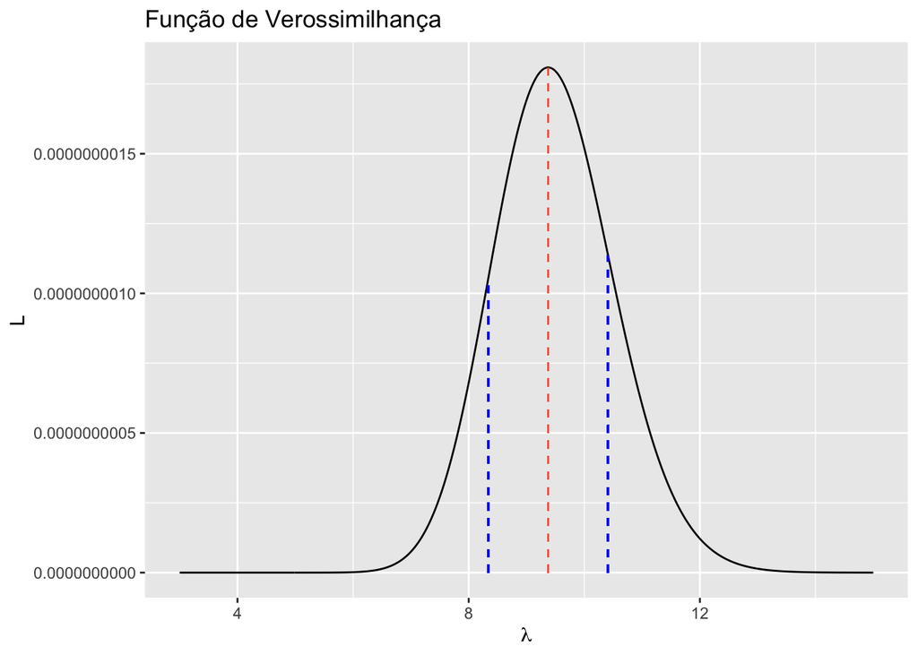

```r
theta_hat <- max_lli$max
theta_inf <- theta_hat - sei
theta_sup <- theta_hat + sei

max_L <- L_pois_i(theta = theta_hat, yi, k1, k2)
min_L <- 0

L_inf <- L_pois_i(theta = theta_inf, y_i, k1, k2)
L_sup <- L_pois_i(theta = theta_sup, y_i, k1, k2)

df_plot = data.frame(theta = theta)
df_plot$L <- sapply(df_plot$theta, FUN = L_pois_i, y_i = y, k1 = k1, k2 = k2)

df_plot %>%
  ggplot(aes(x = theta, y = L)) +
  geom_line() +
  labs(title = 'Função de Verossimilhança', x = expression(lambda), y = expression(L)) +
  xlim(3, 15) +
  geom_segment(
    aes(x = theta_hat, y = min_L, xend = theta_hat, yend = max_L),
    linetype = 'dashed', colour = 'tomato') +
  geom_segment(
    aes(x = theta_inf, y = min_L, xend = theta_inf, yend = L_inf),
    linetype = 'dashed', colour = 'blue') +
  geom_segment(
    aes(x = theta_sup, y = min_L, xend = theta_sup, yend = L_sup),
    linetype = 'dashed', colour = 'blue')
```